Auteur: **Ouedraogo Ami Samyra**

# Étudier un ensemble de données

## Table des matières

- Introduction
- Data Wrangling
- Exploratory Data Analysis
- Conclusions

### ANALYSE DES DONNEES DE FOOTBALL DES LIGUES EUROPEENNES

## Introduction

#### Questions

1- quelle est la proportion des joueurs preferant jouer avec le pieds droit par rapport a ceux preferrant le pied gauche et ce parametre a t'il de l'influence sur le potential ou la note du jouer?

2- A quoi ressembele la repartition en age des joueurs ?

3- quelle characteristique a un impact sur le scoring des joueurs?

4- exist t'il une relation entre le poids , la taille et la valeur de note moyenne des joueurs?

6- quel est le top 10 des joueurs ayant du haut potentiels ?

7-quelle saison de la ligue 1 de france a comptabilisé le plus de but?

8-combien de match ont été joués / chaque league?

9-quelles sont les meilleurs equipes des derniere season la derniere année pour chaque league en terme de nombre de but?

```python
# Importer les librairies

#librairie pour gerer les fichiers sqlite
import sqlite3
#
import pandas as pd
import numpy as np
#libraries pour l'exploration des données
import matplotlib.pyplot as plt
import seaborn as sns
```

## Data Wrangling

### Collecter les données

#### Create a SQL connection to our SQLite database

```python
# Importer le dataset

con = sqlite3.connect("database.sqlite")
```

```python
query = lambda x: pd.read_sql_query(x, con)
```

#### check du nombre de tables present dans ma base de données

```python
tables = pd.read_sql("""SELECT tbl_name,sql,rootpage
                        FROM sqlite_master
                        WHERE type='table';""", con)
tables
```

|  | tbl_name | sql | rootpage |
| --- | --- | --- | --- |
| 0 | sqlite_sequence | CREATE TABLE sqlite_sequence(name,seq) | 4 |
| 1 | Player_Attributes | CREATE TABLE "Player_Attributes" (\n\t`id`\tIN... | 11 |
| 2 | Player | CREATE TABLE `Player` (\n\t`id`\tINTEGER PRIMA... | 14 |
| 3 | Match | CREATE TABLE `Match` (\n\t`id`\tINTEGER PRIMAR... | 18 |
| 4 | League | CREATE TABLE `League` (\n\t`id`\tINTEGER PRIMA... | 24 |
| 5 | Country | CREATE TABLE `Country` (\n\t`id`\tINTEGER PRIM... | 26 |
| 6 | Team | CREATE TABLE "Team" (\n\t`id`\tINTEGER PRIMARY... | 29 |
| 7 | Team_Attributes | CREATE TABLE `Team_Attributes` (\n\t`id`\tINTE... | 2 |

#### chargement de la table League

```python
League=pd.read_sql("""SELECT *FROM League;""", con)
League
```

|  | id | country_id | name |
| --- | --- | --- | --- |
| 0 | 1 | 1 | Belgium Jupiler League |
| 1 | 1729 | 1729 | England Premier League |
| 2 | 4769 | 4769 | France Ligue 1 |
| 3 | 7809 | 7809 | Germany 1. Bundesliga |
| 4 | 10257 | 10257 | Italy Serie A |
| 5 | 13274 | 13274 | Netherlands Eredivisie |
| 6 | 15722 | 15722 | Poland Ekstraklasa |
| 7 | 17642 | 17642 | Portugal Liga ZON Sagres |
| 8 | 19694 | 19694 | Scotland Premier League |
| 9 | 21518 | 21518 | Spain LIGA BBVA |
| 10 | 24558 | 24558 | Switzerland Super League |

```python
League.info()
```

```
<class 'pandas.core.frame.DataFrame'>
RangeIndex: 11 entries, 0 to 10
Data columns (total 3 columns):
 #   Column      Non-Null Count  Dtype
---  ------      --------------  -----
 0   id          11 non-null     int64
 1   country_id  11 non-null     int64
 2   name        11 non-null     object
dtypes: int64(2), object(1)
memory usage: 392.0+ bytes
```

#### chargement de la table country

```python
Country=pd.read_sql("""SELECT *FROM Country;""", con)
Country
```

|  | id | name |
| --- | --- | --- |
| 0 | 1 | Belgium |
| 1 | 1729 | England |
| 2 | 4769 | France |
| 3 | 7809 | Germany |
| 4 | 10257 | Italy |
| 5 | 13274 | Netherlands |
| 6 | 15722 | Poland |
| 7 | 17642 | Portugal |
| 8 | 19694 | Scotland |
| 9 | 21518 | Spain |
| 10 | 24558 | Switzerland |

```python
Country.info()
```

```
<class 'pandas.core.frame.DataFrame'>
RangeIndex: 11 entries, 0 to 10
Data columns (total 2 columns):
 #   Column  Non-Null Count  Dtype
---  ------  --------------  -----
 0   id      11 non-null     int64
 1   name    11 non-null     object
dtypes: int64(1), object(1)
memory usage: 304.0+ bytes
```

#### chargement de la table Team

```python
Team=pd.read_sql("""SELECT *FROM Team;""", con)
Team.head()
```

|  | id | team_api_id | team_fifa_api_id | team_long_name | team_short_name |
| --- | --- | --- | --- | --- | --- |
| 0 | 1 | 9987 | 673.0 | KRC Genk | GEN |
| 1 | 2 | 9993 | 675.0 | Beerschot AC | BAC |
| 2 | 3 | 10000 | 15005.0 | SV Zulte-Waregem | ZUL |
| 3 | 4 | 9994 | 2007.0 | Sporting Lokeren | LOK |
| 4 | 5 | 9984 | 1750.0 | KSV Cercle Brugge | CEB |

```python
Team.info()
```

```
<class 'pandas.core.frame.DataFrame'>
RangeIndex: 299 entries, 0 to 298
Data columns (total 5 columns):
 #   Column            Non-Null Count  Dtype
---  ------            --------------  -----
 0   id                299 non-null    int64
 1   team_api_id       299 non-null    int64
 2   team_fifa_api_id  288 non-null    float64
 3   team_long_name    299 non-null    object
 4   team_short_name   299 non-null    object
dtypes: float64(1), int64(2), object(2)
memory usage: 11.8+ KB
```

#### chargement de la table Match

```python
Match=pd.read_sql("""SELECT *FROM Match;""", con)
Match['BWA']
```

```
0        4.20
1        3.95
2        2.55
3        6.80
4        1.60
         ...
25974     NaN
25975     NaN
25976     NaN
25977     NaN
25978     NaN
Name: BWA, Length: 25979, dtype: float64
```

```python
Match.info()
```

```
<class 'pandas.core.frame.DataFrame'>
RangeIndex: 25979 entries, 0 to 25978
Columns: 115 entries, id to BSA
dtypes: float64(96), int64(9), object(10)
memory usage: 22.8+ MB
```

#### chargement de la table season

```python
season=Match["season"].unique()
season
```

```
array(['2008/2009', '2009/2010', '2010/2011', '2011/2012', '2012/2013',
       '2013/2014', '2014/2015', '2015/2016'], dtype=object)
```

```python
Match.sample(5)
```

|  | id | country_id | league_id | season | stage | date | match_api_id | home_team_api_id | away_team_api_id | home_team_goal | ... | SJA | VCH | VCD | VCA | GBH | GBD | GBA | BSH | BSD | BSA |
| --- | --- | --- | --- | --- | --- | --- | --- | --- | --- | --- | --- | --- | --- | --- | --- | --- | --- | --- | --- | --- | --- |
| 361 | 362 | 1 | 1 | 2009/2010 | 16 | 2009-11-28 00:00:00 | 665596 | 9993 | 9999 | 3 | ... | 9.5 | 1.30 | 4.50 | 8.5 | 1.30 | 4.5 | 9.00 | 1.30 | 4.5 | 8.50 |
| 18456 | 18457 | 17642 | 17642 | 2011/2012 | 2 | 2011-08-21 00:00:00 | 1042845 | 10264 | 10212 | 2 | ... | 6.5 | 1.57 | 3.75 | 6.0 | 1.60 | 3.5 | 5.50 | 1.62 | 3.4 | 5.50 |
| 23397 | 23398 | 21518 | 21518 | 2012/2013 | 8 | 2012-10-21 00:00:00 | 1260087 | 8558 | 8370 | 3 | ... | 3.8 | 1.92 | 3.80 | 4.1 | 1.87 | 3.5 | 4.00 | 1.91 | 3.6 | 3.60 |
| 2107 | 2108 | 1729 | 1729 | 2008/2009 | 9 | 2008-10-26 00:00:00 | 489131 | 8455 | 8650 | 0 | ... | 4.5 | 1.85 | 3.30 | 4.9 | 1.95 | 3.2 | 4.20 | 1.91 | 3.2 | 4.33 |
| 2156 | 2157 | 1729 | 1729 | 2009/2010 | 13 | 2009-11-22 00:00:00 | 658797 | 8586 | 8528 | 9 | ... | 8.0 | 1.40 | 4.33 | 7.5 | 1.45 | 4.0 | 7.25 | 1.44 | 4.0 | 8.00 |

5 rows × 115 columns

#### chargement des données d'analyse de match grace a la jointure des tables Match ,League,season et Team

```python
detailed_matches = pd.read_sql("""SELECT Match.id,
                                        Country.name AS country_name,
                                        League.name AS league_name,
                                        season,
                                        stage,
                                        date,
                                        HT.team_long_name AS  home_team,
                                        AT.team_long_name AS away_team,
                                        home_team_goal,
                                        away_team_goal
                                FROM Match

                                JOIN Country on Country.id = Match.country_id
                                JOIN League on League.id = Match.league_id
                                LEFT JOIN Team AS HT on HT.team_api_id = Match.home_team_api_id
                                LEFT JOIN Team AS AT on AT.team_api_id = Match.away_team_api_id

                                ORDER by date
                                ;""", con)
detailed_matches.sample(5)
```

|  | id | country_name | league_name | season | stage | date | home_team | away_team | home_team_goal | away_team_goal |
| --- | --- | --- | --- | --- | --- | --- | --- | --- | --- | --- |
| 13623 | 23383 | Spain | Spain LIGA BBVA | 2012/2013 | 6 | 2012-09-29 00:00:00 | Valencia CF | Real Zaragoza | 2 | 0 |
| 20751 | 23854 | Spain | Spain LIGA BBVA | 2014/2015 | 14 | 2014-12-07 00:00:00 | Granada CF | Valencia CF | 1 | 1 |
| 1908 | 13399 | Netherlands | Netherlands Eredivisie | 2008/2009 | 21 | 2009-02-05 00:00:00 | PSV | ADO Den Haag | 6 | 0 |
| 17725 | 6778 | France | France Ligue 1 | 2013/2014 | 19 | 2013-12-21 00:00:00 | Toulouse FC | En Avant de Guingamp | 0 | 0 |
| 19129 | 1248 | Belgium | Belgium Jupiler League | 2013/2014 | 6 | 2014-05-03 00:00:00 | KAA Gent | Lierse SK | 4 | 0 |

#### recuperation de la liste des equipes de la ligue francaise

```python
team_france=Match[Match["league_id"]==4769]
e1=team_france["home_team_api_id"].unique()
e2=team_france["away_team_api_id"].unique()

resultList= list(set(e1) | set(e2))
resultList
```

```
[8576,
 10242,
 8583,
 10249,
 7819,
 8588,
 8592,
 9873,
 9746,
 9874,
 9748,
 9747,
 6391,
 8481,
 8121,
 8639,
 8521,
 4170,
 4087,
 9941,
 108893,
 9827,
 9829,
 9830,
 9831,
 8550,
 8682,
 9836,
 9837,
 8689,
 7794,
 9847,
 9851,
 9853,
 9855]
```

#### récupération de quelques characteristiques de la table Team

```python
Team=query("select team_long_name,team_api_id from Team ")
Team.head()
Team
```

|  | team_long_name | team_api_id |
| --- | --- | --- |
| 0 | KRC Genk | 9987 |
| 1 | Beerschot AC | 9993 |
| 2 | SV Zulte-Waregem | 10000 |
| 3 | Sporting Lokeren | 9994 |
| 4 | KSV Cercle Brugge | 9984 |
| ... | ... | ... |
| 294 | FC St. Gallen | 10190 |
| 295 | FC Thun | 10191 |
| 296 | Servette FC | 9777 |
| 297 | FC Lausanne-Sports | 7730 |
| 298 | Lugano | 7896 |

299 rows × 2 columns

#### filtre pour récuperer unique la liste des équipes de la ligue de france

```python
team_fleague1=Team.query(f'team_api_id=={resultList}')
```

```python
team_fleague1
```

|  | team_long_name | team_api_id |
| --- | --- | --- |
| 59 | AJ Auxerre | 8583 |
| 60 | FC Nantes | 9830 |
| 61 | Girondins de Bordeaux | 9827 |
| 62 | SM Caen | 7819 |
| 63 | Le Havre AC | 9746 |
| 64 | OGC Nice | 9831 |
| 65 | Le Mans FC | 8682 |
| 66 | FC Lorient | 8689 |
| 67 | Olympique Lyonnais | 9748 |
| 68 | Toulouse FC | 9941 |
| 69 | AS Monaco | 9829 |
| 70 | Paris Saint-Germain | 9847 |
| 71 | AS Nancy-Lorraine | 8481 |
| 72 | LOSC Lille | 8639 |
| 73 | Stade Rennais FC | 9851 |
| 74 | Olympique de Marseille | 8592 |
| 75 | FC Sochaux-Montbéliard | 9874 |
| 76 | Grenoble Foot 38 | 9855 |
| 77 | Valenciennes FC | 9873 |
| 78 | AS Saint-Étienne | 9853 |
| 79 | RC Lens | 8588 |
| 80 | Montpellier Hérault SC | 10249 |
| 81 | US Boulogne Cote D'Opale | 4170 |
| 82 | AC Arles-Avignon | 108893 |
| 83 | Stade Brestois 29 | 8521 |
| 84 | AC Ajaccio | 8576 |
| 85 | Évian Thonon Gaillard FC | 4087 |
| 86 | Dijon FCO | 9836 |
| 87 | Stade de Reims | 9837 |
| 88 | SC Bastia | 7794 |
| 89 | ES Troyes AC | 10242 |
| 90 | En Avant de Guingamp | 9747 |
| 91 | FC Metz | 8550 |
| 92 | Angers SCO | 8121 |
| 93 | GFC Ajaccio | 6391 |

#### récuperation des données de la table Player_Attribute

```python
Player_Attribute=pd.read_sql("""SELECT *FROM Player_Attributes;""", con)
Player_Attribute.head()
```

|  | id | player_fifa_api_id | player_api_id | date | overall_rating | potential | preferred_foot | attacking_work_rate | defensive_work_rate | crossing | ... | vision | penalties | marking | standing_tackle | sliding_tackle | gk_diving | gk_handling | gk_kicking | gk_positioning | gk_reflexes |
| --- | --- | --- | --- | --- | --- | --- | --- | --- | --- | --- | --- | --- | --- | --- | --- | --- | --- | --- | --- | --- | --- |
| 0 | 1 | 218353 | 505942 | 2016-02-18 00:00:00 | 67.0 | 71.0 | right | medium | medium | 49.0 | ... | 54.0 | 48.0 | 65.0 | 69.0 | 69.0 | 6.0 | 11.0 | 10.0 | 8.0 | 8.0 |
| 1 | 2 | 218353 | 505942 | 2015-11-19 00:00:00 | 67.0 | 71.0 | right | medium | medium | 49.0 | ... | 54.0 | 48.0 | 65.0 | 69.0 | 69.0 | 6.0 | 11.0 | 10.0 | 8.0 | 8.0 |
| 2 | 3 | 218353 | 505942 | 2015-09-21 00:00:00 | 62.0 | 66.0 | right | medium | medium | 49.0 | ... | 54.0 | 48.0 | 65.0 | 66.0 | 69.0 | 6.0 | 11.0 | 10.0 | 8.0 | 8.0 |
| 3 | 4 | 218353 | 505942 | 2015-03-20 00:00:00 | 61.0 | 65.0 | right | medium | medium | 48.0 | ... | 53.0 | 47.0 | 62.0 | 63.0 | 66.0 | 5.0 | 10.0 | 9.0 | 7.0 | 7.0 |
| 4 | 5 | 218353 | 505942 | 2007-02-22 00:00:00 | 61.0 | 65.0 | right | medium | medium | 48.0 | ... | 53.0 | 47.0 | 62.0 | 63.0 | 66.0 | 5.0 | 10.0 | 9.0 | 7.0 | 7.0 |

5 rows × 42 columns

```python
Player_Attribute.info()
```

```
<class 'pandas.core.frame.DataFrame'>
RangeIndex: 183978 entries, 0 to 183977
Data columns (total 42 columns):
 #   Column               Non-Null Count   Dtype
---  ------               --------------   -----
 0   id                   183978 non-null  int64
 1   player_fifa_api_id   183978 non-null  int64
 2   player_api_id        183978 non-null  int64
 3   date                 183978 non-null  object
 4   overall_rating       183142 non-null  float64
 5   potential            183142 non-null  float64
 6   preferred_foot       183142 non-null  object
 7   attacking_work_rate  180748 non-null  object
 8   defensive_work_rate  183142 non-null  object
 9   crossing             183142 non-null  float64
```

[output cut: 34 more lines]

#### chargement de la table Player

```python
Player=pd.read_sql("""SELECT *FROM Player;""", con)
Player.head()
```

|  | id | player_api_id | player_name | player_fifa_api_id | birthday | height | weight |
| --- | --- | --- | --- | --- | --- | --- | --- |
| 0 | 1 | 505942 | Aaron Appindangoye | 218353 | 1992-02-29 00:00:00 | 182.88 | 187 |
| 1 | 2 | 155782 | Aaron Cresswell | 189615 | 1989-12-15 00:00:00 | 170.18 | 146 |
| 2 | 3 | 162549 | Aaron Doran | 186170 | 1991-05-13 00:00:00 | 170.18 | 163 |
| 3 | 4 | 30572 | Aaron Galindo | 140161 | 1982-05-08 00:00:00 | 182.88 | 198 |
| 4 | 5 | 23780 | Aaron Hughes | 17725 | 1979-11-08 00:00:00 | 182.88 | 154 |

```python
Player.info()
```

```
<class 'pandas.core.frame.DataFrame'>
RangeIndex: 11060 entries, 0 to 11059
Data columns (total 7 columns):
 #   Column              Non-Null Count  Dtype
---  ------              --------------  -----
 0   id                  11060 non-null  int64
 1   player_api_id       11060 non-null  int64
 2   player_name         11060 non-null  object
 3   player_fifa_api_id  11060 non-null  int64
 4   birthday            11060 non-null  object
 5   height              11060 non-null  float64
 6   weight              11060 non-null  int64
dtypes: float64(1), int64(4), object(2)
memory usage: 605.0+ KB
```

#### verifier si il existe des joueurs avec le meme nom

```python
#number of player
Player["player_name"].value_counts()
Player[Player["player_name"]=="Danilo"]
```

|  | id | player_api_id | player_name | player_fifa_api_id | birthday | height | weight |
| --- | --- | --- | --- | --- | --- | --- | --- |
| 2211 | 2214 | 143403 | Danilo | 201635 | 1986-11-11 00:00:00 | 185.42 | 176 |
| 2212 | 2215 | 185909 | Danilo | 199753 | 1979-08-13 00:00:00 | 172.72 | 148 |
| 2213 | 2216 | 19249 | Danilo | 166072 | 1984-05-10 00:00:00 | 185.42 | 165 |
| 2214 | 2217 | 208077 | Danilo | 199304 | 1991-07-15 00:00:00 | 182.88 | 172 |
| 2215 | 2218 | 208943 | Danilo | 199946 | 1990-01-13 00:00:00 | 172.72 | 159 |
| 2216 | 2219 | 281339 | Danilo | 205543 | 1985-05-28 00:00:00 | 175.26 | 159 |
| 2217 | 2220 | 570432 | Danilo | 223517 | 1996-02-28 00:00:00 | 182.88 | 163 |

#### nombre exacte de joueurs dans ma base de données

```python
nbplayers=Player["player_api_id"].nunique()
nbplayers
```

```
11060
```

```python
players=pd.read_sql("""SELECT t.player_api_id,ta.player_name,t.overall_rating,t.date,t.potential,t.preferred_foot,t.penalties,t.marking,ta.birthday,ta.height,ta.weight
                        FROM Player as ta JOIN Player_Attributes as t ON ta.player_api_id = t.player_api_id;""", con);
```

```python
players
```

|  | player_api_id | player_name | overall_rating | date | potential | preferred_foot | penalties | marking | birthday | height | weight |
| --- | --- | --- | --- | --- | --- | --- | --- | --- | --- | --- | --- |
| 0 | 505942 | Aaron Appindangoye | 67.0 | 2016-02-18 00:00:00 | 71.0 | right | 48.0 | 65.0 | 1992-02-29 00:00:00 | 182.88 | 187 |
| 1 | 505942 | Aaron Appindangoye | 67.0 | 2015-11-19 00:00:00 | 71.0 | right | 48.0 | 65.0 | 1992-02-29 00:00:00 | 182.88 | 187 |
| 2 | 505942 | Aaron Appindangoye | 62.0 | 2015-09-21 00:00:00 | 66.0 | right | 48.0 | 65.0 | 1992-02-29 00:00:00 | 182.88 | 187 |
| 3 | 505942 | Aaron Appindangoye | 61.0 | 2015-03-20 00:00:00 | 65.0 | right | 47.0 | 62.0 | 1992-02-29 00:00:00 | 182.88 | 187 |
| 4 | 505942 | Aaron Appindangoye | 61.0 | 2007-02-22 00:00:00 | 65.0 | right | 47.0 | 62.0 | 1992-02-29 00:00:00 | 182.88 | 187 |
| ... | ... | ... | ... | ... | ... | ... | ... | ... | ... | ... | ... |
| 183973 | 39902 | Zvjezdan Misimovic | 83.0 | 2009-08-30 00:00:00 | 85.0 | right | 83.0 | 22.0 | 1982-06-05 00:00:00 | 180.34 | 176 |
| 183974 | 39902 | Zvjezdan Misimovic | 78.0 | 2009-02-22 00:00:00 | 80.0 | right | 70.0 | 32.0 | 1982-06-05 00:00:00 | 180.34 | 176 |
| 183975 | 39902 | Zvjezdan Misimovic | 77.0 | 2008-08-30 00:00:00 | 80.0 | right | 70.0 | 32.0 | 1982-06-05 00:00:00 | 180.34 | 176 |
| 183976 | 39902 | Zvjezdan Misimovic | 78.0 | 2007-08-30 00:00:00 | 81.0 | right | 53.0 | 28.0 | 1982-06-05 00:00:00 | 180.34 | 176 |
| 183977 | 39902 | Zvjezdan Misimovic | 80.0 | 2007-02-22 00:00:00 | 81.0 | right | 53.0 | 38.0 | 1982-06-05 00:00:00 | 180.34 | 176 |

183978 rows × 11 columns

#### chargement de la table Team_Attributes

```python
Team_Attributes=pd.read_sql("""SELECT *FROM Team_Attributes;""", con)
Team_Attributes.head()
```

|  | id | team_fifa_api_id | team_api_id | date | buildUpPlaySpeed | buildUpPlaySpeedClass | buildUpPlayDribbling | buildUpPlayDribblingClass | buildUpPlayPassing | buildUpPlayPassingClass | ... | chanceCreationShooting | chanceCreationShootingClass | chanceCreationPositioningClass | defencePressure | defencePressureClass | defenceAggression | defenceAggressionClass | defenceTeamWidth | defenceTeamWidthClass | defenceDefenderLineClass |
| --- | --- | --- | --- | --- | --- | --- | --- | --- | --- | --- | --- | --- | --- | --- | --- | --- | --- | --- | --- | --- | --- |
| 0 | 1 | 434 | 9930 | 2010-02-22 00:00:00 | 60 | Balanced | NaN | Little | 50 | Mixed | ... | 55 | Normal | Organised | 50 | Medium | 55 | Press | 45 | Normal | Cover |
| 1 | 2 | 434 | 9930 | 2014-09-19 00:00:00 | 52 | Balanced | 48.0 | Normal | 56 | Mixed | ... | 64 | Normal | Organised | 47 | Medium | 44 | Press | 54 | Normal | Cover |
| 2 | 3 | 434 | 9930 | 2015-09-10 00:00:00 | 47 | Balanced | 41.0 | Normal | 54 | Mixed | ... | 64 | Normal | Organised | 47 | Medium | 44 | Press | 54 | Normal | Cover |
| 3 | 4 | 77 | 8485 | 2010-02-22 00:00:00 | 70 | Fast | NaN | Little | 70 | Long | ... | 70 | Lots | Organised | 60 | Medium | 70 | Double | 70 | Wide | Cover |
| 4 | 5 | 77 | 8485 | 2011-02-22 00:00:00 | 47 | Balanced | NaN | Little | 52 | Mixed | ... | 52 | Normal | Organised | 47 | Medium | 47 | Press | 52 | Normal | Cover |

5 rows × 25 columns

```python
Team_Attributes.info()
```

```
<class 'pandas.core.frame.DataFrame'>
RangeIndex: 1458 entries, 0 to 1457
Data columns (total 25 columns):
 #   Column                          Non-Null Count  Dtype
---  ------                          --------------  -----
 0   id                              1458 non-null   int64
 1   team_fifa_api_id                1458 non-null   int64
 2   team_api_id                     1458 non-null   int64
 3   date                            1458 non-null   object
 4   buildUpPlaySpeed                1458 non-null   int64
 5   buildUpPlaySpeedClass           1458 non-null   object
 6   buildUpPlayDribbling            489 non-null    float64
 7   buildUpPlayDribblingClass       1458 non-null   object
 8   buildUpPlayPassing              1458 non-null   int64
 9   buildUpPlayPassingClass         1458 non-null   object
```

[output cut: 17 more lines]

```python
Team_Attributes.describe()
```

|  | id | team_fifa_api_id | team_api_id | buildUpPlaySpeed | buildUpPlayDribbling | buildUpPlayPassing | chanceCreationPassing | chanceCreationCrossing | chanceCreationShooting | defencePressure | defenceAggression | defenceTeamWidth |
| --- | --- | --- | --- | --- | --- | --- | --- | --- | --- | --- | --- | --- |
| count | 1458.000000 | 1458.000000 | 1458.000000 | 1458.000000 | 489.000000 | 1458.000000 | 1458.000000 | 1458.000000 | 1458.000000 | 1458.000000 | 1458.000000 | 1458.000000 |
| mean | 729.500000 | 17706.982167 | 9995.727023 | 52.462277 | 48.607362 | 48.490398 | 52.165295 | 53.731824 | 53.969136 | 46.017147 | 49.251029 | 52.185871 |
| std | 421.032659 | 39179.857739 | 13264.869900 | 11.545869 | 9.678290 | 10.896101 | 10.360793 | 11.086796 | 10.327566 | 10.227225 | 9.738028 | 9.574712 |
| min | 1.000000 | 1.000000 | 1601.000000 | 20.000000 | 24.000000 | 20.000000 | 21.000000 | 20.000000 | 22.000000 | 23.000000 | 24.000000 | 29.000000 |
| 25% | 365.250000 | 110.000000 | 8457.750000 | 45.000000 | 42.000000 | 40.000000 | 46.000000 | 47.000000 | 48.000000 | 39.000000 | 44.000000 | 47.000000 |
| 50% | 729.500000 | 485.000000 | 8674.000000 | 52.000000 | 49.000000 | 50.000000 | 52.000000 | 53.000000 | 53.000000 | 45.000000 | 48.000000 | 52.000000 |
| 75% | 1093.750000 | 1900.000000 | 9904.000000 | 62.000000 | 55.000000 | 55.000000 | 59.000000 | 62.000000 | 61.000000 | 51.000000 | 55.000000 | 58.000000 |
| max | 1458.000000 | 112513.000000 | 274581.000000 | 80.000000 | 77.000000 | 80.000000 | 80.000000 | 80.000000 | 80.000000 | 72.000000 | 72.000000 | 73.000000 |

```python
Teams=query("""Select t.team_api_id,team_long_name,team_short_name,date,chanceCreationShootingClass,chanceCreationPositioningClass,defencePressureClass,defenceDefenderLineClass from Team t join Team_Attributes ta on t.team_api_id=ta.team_api_id""")
```

```python
Teams.query(f'team_api_id=={resultList}')
```

|  | team_api_id | team_long_name | team_short_name | date | chanceCreationShootingClass | chanceCreationPositioningClass | defencePressureClass | defenceDefenderLineClass |
| --- | --- | --- | --- | --- | --- | --- | --- | --- |
| 9 | 8576 | AC Ajaccio | AJA | 2010-02-22 00:00:00 | Normal | Organised | Deep | Offside Trap |
| 10 | 8576 | AC Ajaccio | AJA | 2011-02-22 00:00:00 | Normal | Organised | Medium | Cover |
| 11 | 8576 | AC Ajaccio | AJA | 2012-02-22 00:00:00 | Normal | Organised | Medium | Cover |
| 12 | 8576 | AC Ajaccio | AJA | 2013-09-20 00:00:00 | Normal | Organised | Medium | Cover |
| 13 | 8576 | AC Ajaccio | AJA | 2014-09-19 00:00:00 | Normal | Organised | Medium | Cover |
| ... | ... | ... | ... | ... | ... | ... | ... | ... |
| 1314 | 9873 | Valenciennes FC | VAL | 2011-02-22 00:00:00 | Normal | Organised | Medium | Cover |
| 1315 | 9873 | Valenciennes FC | VAL | 2012-02-22 00:00:00 | Normal | Organised | Medium | Cover |
| 1316 | 9873 | Valenciennes FC | VAL | 2013-09-20 00:00:00 | Normal | Organised | Medium | Cover |
| 1317 | 9873 | Valenciennes FC | VAL | 2014-09-19 00:00:00 | Normal | Organised | Medium | Cover |
| 1318 | 9873 | Valenciennes FC | VAL | 2015-09-10 00:00:00 | Normal | Organised | Medium | Cover |

191 rows × 8 columns

```python
#Creating Function for Barh Plot
def Barplot(data_name,plot_title,x_label,y_label):
    data_name.plot(kind = 'barh',figsize = (10,6))
    plt.title(plot_title)
    plt.xlabel(x_label)
    plt.ylabel(y_label)
    plt.show()
```

- Cependant pour répondre au differentes questions dans la table player ,il serait plus adequat au lieu de la date d'anniversaire du joueur d'avoir son age

## Nettoyage des données

#### definir

- convertir la colonne birthday de la la table player en datetime et la tranformer en age grace a une fonction qui me permettra de calculer l'age a partir de la date

#### coder

##### fonction pour calculer l'age a partir de la date de naissance

```python
from datetime import date

def calculateAge(birthDate):
    today = date.today()
    age = today.year - birthDate.year - ((today.month, today.day) < (birthDate.month, birthDate.day))
    return age
```

##### convertir mes colonnes birthday an date en datetime

```python
players[['birthday','date']]=players[['birthday','date']].apply(lambda x :pd.to_datetime(x))
```

```python
#### Appliquer la fonction age
```

```python
players['age']=players['birthday'].apply(lambda x: calculateAge(x))
```

#### tester

```python
players.head(10)
```

|  | player_api_id | player_name | overall_rating | date | potential | preferred_foot | penalties | marking | birthday | height | weight | age |
| --- | --- | --- | --- | --- | --- | --- | --- | --- | --- | --- | --- | --- |
| 0 | 505942 | Aaron Appindangoye | 67.0 | 2016-02-18 | 71.0 | right | 48.0 | 65.0 | 1992-02-29 | 182.88 | 187 | 30 |
| 1 | 505942 | Aaron Appindangoye | 67.0 | 2015-11-19 | 71.0 | right | 48.0 | 65.0 | 1992-02-29 | 182.88 | 187 | 30 |
| 2 | 505942 | Aaron Appindangoye | 62.0 | 2015-09-21 | 66.0 | right | 48.0 | 65.0 | 1992-02-29 | 182.88 | 187 | 30 |
| 3 | 505942 | Aaron Appindangoye | 61.0 | 2015-03-20 | 65.0 | right | 47.0 | 62.0 | 1992-02-29 | 182.88 | 187 | 30 |
| 4 | 505942 | Aaron Appindangoye | 61.0 | 2007-02-22 | 65.0 | right | 47.0 | 62.0 | 1992-02-29 | 182.88 | 187 | 30 |
| 5 | 155782 | Aaron Cresswell | 74.0 | 2016-04-21 | 76.0 | left | 59.0 | 76.0 | 1989-12-15 | 170.18 | 146 | 32 |
| 6 | 155782 | Aaron Cresswell | 74.0 | 2016-04-07 | 76.0 | left | 59.0 | 76.0 | 1989-12-15 | 170.18 | 146 | 32 |
| 7 | 155782 | Aaron Cresswell | 73.0 | 2016-01-07 | 75.0 | left | 59.0 | 76.0 | 1989-12-15 | 170.18 | 146 | 32 |
| 8 | 155782 | Aaron Cresswell | 73.0 | 2015-12-24 | 75.0 | left | 59.0 | 76.0 | 1989-12-15 | 170.18 | 146 | 32 |
| 9 | 155782 | Aaron Cresswell | 73.0 | 2015-12-17 | 75.0 | left | 59.0 | 76.0 | 1989-12-15 | 170.18 | 146 | 32 |

## L'analyse exploratoire des données

### Question de recherche 1(quelle est la proportion des joueurs preferant jouer avec le pieds droit par rapport a ceux preferrant le pied gauche et ce parametre a t'il de l'influence sur le potential ou la note du joueur? )

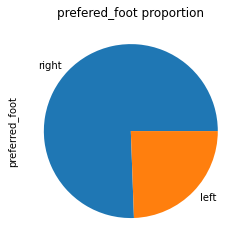

```python
#Code

#Plot
players["preferred_foot"].value_counts().plot(kind="pie",title="prefered_foot proportion");
```

**Conclusion**

3/4 des joueurs ont pour pieds de preference le pied droit que le pied gauche

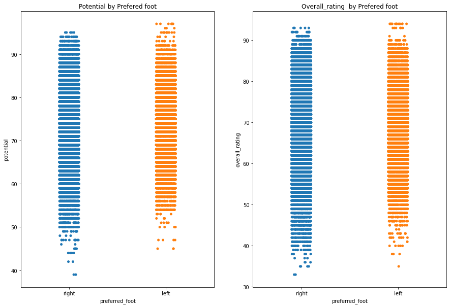

```python
#plt.scatter(players["preferred_foot"], players["potential"])
fig,(ax1,ax2)=plt.subplots(1,2,figsize=(15,10))
sns.stripplot(ax=ax1,x="preferred_foot", y="potential", data=players).set(title='Potential by Prefered foot');
sns.stripplot(ax=ax2,x="preferred_foot", y="overall_rating", data=players).set(title='Overall_rating  by Prefered foot');
```

**Conclusion**

nous pouvons voir ici qu'il n'existe pas de relation entre le pied de preferance et le potentiel du joueur

### Question de recherche 2 (A quoi ressembele la repartition en age des joueurs ? )

```python
#age moyen d'un joueur
players.age.mean()
```

```
34.90168933242018
```

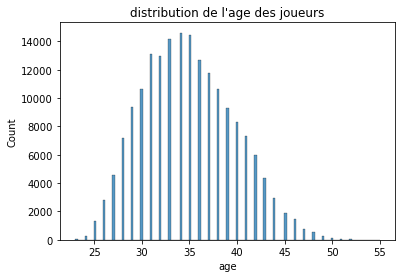

```python
sns.histplot(data=players,x="age").set(title="distribution de l'age des joueurs");

#players["age"].value_counts().plot(kind="bar")
```

**Conclusion**

cette courbe montre que la plupart des jours ont entre 30 et 40 ans

### Question de recherche 3 (quelles characteristiques a un impact sur la note des joueurs? )

```python
players
```

|  | player_api_id | player_name | overall_rating | date | potential | preferred_foot | penalties | marking | birthday | height | weight | age |
| --- | --- | --- | --- | --- | --- | --- | --- | --- | --- | --- | --- | --- |
| 0 | 505942 | Aaron Appindangoye | 67.0 | 2016-02-18 | 71.0 | right | 48.0 | 65.0 | 1992-02-29 | 182.88 | 187 | 30 |
| 1 | 505942 | Aaron Appindangoye | 67.0 | 2015-11-19 | 71.0 | right | 48.0 | 65.0 | 1992-02-29 | 182.88 | 187 | 30 |
| 2 | 505942 | Aaron Appindangoye | 62.0 | 2015-09-21 | 66.0 | right | 48.0 | 65.0 | 1992-02-29 | 182.88 | 187 | 30 |
| 3 | 505942 | Aaron Appindangoye | 61.0 | 2015-03-20 | 65.0 | right | 47.0 | 62.0 | 1992-02-29 | 182.88 | 187 | 30 |
| 4 | 505942 | Aaron Appindangoye | 61.0 | 2007-02-22 | 65.0 | right | 47.0 | 62.0 | 1992-02-29 | 182.88 | 187 | 30 |
| ... | ... | ... | ... | ... | ... | ... | ... | ... | ... | ... | ... | ... |
| 183973 | 39902 | Zvjezdan Misimovic | 83.0 | 2009-08-30 | 85.0 | right | 83.0 | 22.0 | 1982-06-05 | 180.34 | 176 | 40 |
| 183974 | 39902 | Zvjezdan Misimovic | 78.0 | 2009-02-22 | 80.0 | right | 70.0 | 32.0 | 1982-06-05 | 180.34 | 176 | 40 |
| 183975 | 39902 | Zvjezdan Misimovic | 77.0 | 2008-08-30 | 80.0 | right | 70.0 | 32.0 | 1982-06-05 | 180.34 | 176 | 40 |
| 183976 | 39902 | Zvjezdan Misimovic | 78.0 | 2007-08-30 | 81.0 | right | 53.0 | 28.0 | 1982-06-05 | 180.34 | 176 | 40 |
| 183977 | 39902 | Zvjezdan Misimovic | 80.0 | 2007-02-22 | 81.0 | right | 53.0 | 38.0 | 1982-06-05 | 180.34 | 176 | 40 |

183978 rows × 12 columns

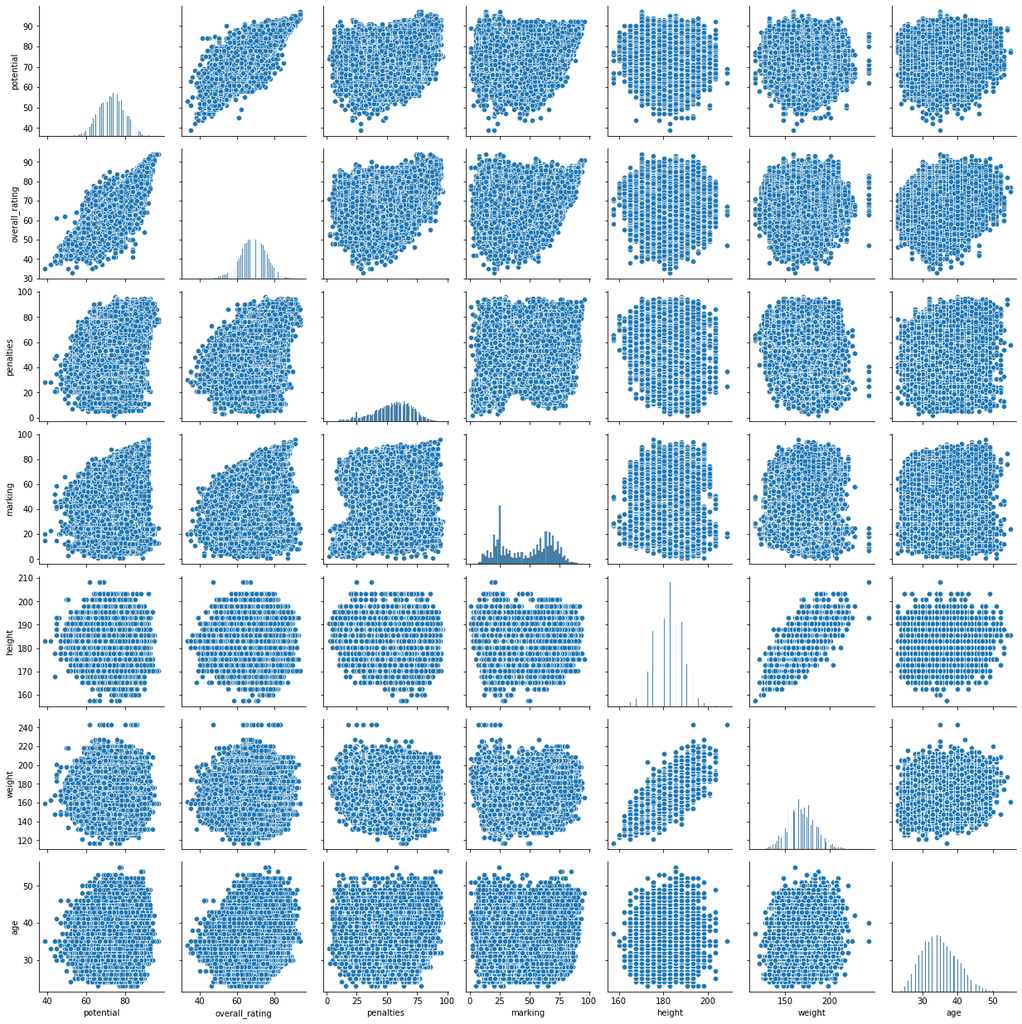

```python
g = sns.PairGrid(players[["potential","overall_rating","penalties","marking","height","weight","age"]])

g.map_diag(sns.histplot);
g.map_offdiag(sns.scatterplot);
#g.map_lower(sns.kdeplot)
#g.map_diag(sns.histplot)
```

**Conclusion**

ici on peut remarque une tendance croissance de la note des joueurs en fonction du potentiel ce serait une variable qui pourrait impacter la note moyenne du joueur

### Question de recherche 4 (exist t'il une relation entre le poids , la taille et la valeur de note moyenne des joueurs? )

```python
#code
# faire une requete directement de ma base de donnes pour recuperer le poids ,la taille et la valeur moyenne la note attribuer
#a un joueur
height_and_ratings = pd.read_sql('''
SELECT pl.player_name as name, pl.height, pl.weight, SUM(overall_rating)/COUNT(*) as avg_rating
FROM PLAYER as pl
JOIN PLAYER_ATTRIBUTES AS pa
ON pa.player_api_id = pl.player_api_id
GROUP BY pl.player_name
''',con)
height_and_ratings.sample(5)
```

|  | name | height | weight | avg_rating |
| --- | --- | --- | --- | --- |
| 5712 | Kieran Richardson | 175.26 | 152 | 74 |
| 8393 | Peter Sladek | 182.88 | 174 | 62 |
| 7664 | Nebojsa Pavlovic | 187.96 | 179 | 67 |
| 4308 | Ioannis Maniatis | 175.26 | 150 | 73 |
| 7032 | Matthew Hill | 170.18 | 174 | 61 |

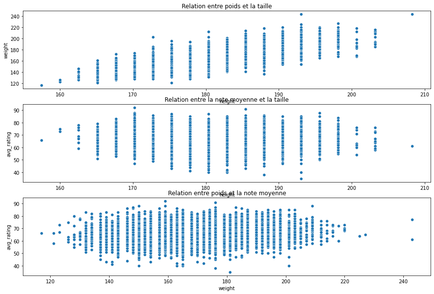

```python
#plot
fig, (ax1, ax2,ax3) = plt.subplots(3, 1,figsize=(15, 10))
plt.figure(figsize=(15,5))
sns.scatterplot(ax=ax1,data=height_and_ratings, x = 'height', y = 'weight').set(title="Relation entre poids et la taille");
sns.scatterplot(ax=ax2,data=height_and_ratings, x = 'height', y = 'avg_rating').set(title="Relation entre la note moyenne et la taille");
sns.scatterplot(ax=ax3,data=height_and_ratings, x = 'weight', y = 'avg_rating').set(title="Relation entre poids et la note moyenne");
```

**Conclusion**

il existe une relation croissante entre la taille et le poids du jours ,plus il est grand plus la valeurs de son poids est elevéemais pas de reel relation entre le poids et la note moyenne et la taille et la note moyenne

```python
#code
#faire une copie de mes données
players2=players.copy()
#recuperer uniquement l'anneé de la date de recordin des information et stocker dans une nouvelle collones
players2['year']=players2['date'].dt.year
#recuperer que les informations des joueurs des 2 dernieres saisons
year=[2014,2015,2016]
players2.query(f'year=={year}')
```

|  | player_api_id | player_name | overall_rating | date | potential | preferred_foot | penalties | marking | birthday | height | weight | age | year |
| --- | --- | --- | --- | --- | --- | --- | --- | --- | --- | --- | --- | --- | --- |
| 0 | 505942 | Aaron Appindangoye | 67.0 | 2016-02-18 | 71.0 | right | 48.0 | 65.0 | 1992-02-29 | 182.88 | 187 | 30 | 2016 |
| 1 | 505942 | Aaron Appindangoye | 67.0 | 2015-11-19 | 71.0 | right | 48.0 | 65.0 | 1992-02-29 | 182.88 | 187 | 30 | 2015 |
| 2 | 505942 | Aaron Appindangoye | 62.0 | 2015-09-21 | 66.0 | right | 48.0 | 65.0 | 1992-02-29 | 182.88 | 187 | 30 | 2015 |
| 3 | 505942 | Aaron Appindangoye | 61.0 | 2015-03-20 | 65.0 | right | 47.0 | 62.0 | 1992-02-29 | 182.88 | 187 | 30 | 2015 |
| 5 | 155782 | Aaron Cresswell | 74.0 | 2016-04-21 | 76.0 | left | 59.0 | 76.0 | 1989-12-15 | 170.18 | 146 | 32 | 2016 |
| ... | ... | ... | ... | ... | ... | ... | ... | ... | ... | ... | ... | ... | ... |
| 183924 | 26357 | Zoumana Camara | 73.0 | 2015-03-06 | 73.0 | right | 50.0 | 76.0 | 1979-04-03 | 182.88 | 168 | 43 | 2015 |
| 183925 | 26357 | Zoumana Camara | 73.0 | 2014-09-18 | 73.0 | right | 50.0 | 76.0 | 1979-04-03 | 182.88 | 168 | 43 | 2014 |
| 183926 | 26357 | Zoumana Camara | 73.0 | 2014-05-16 | 73.0 | right | 50.0 | 76.0 | 1979-04-03 | 182.88 | 168 | 43 | 2014 |
| 183937 | 111182 | Zsolt Laczko | 63.0 | 2014-09-18 | 67.0 | left | 53.0 | 57.0 | 1986-12-18 | 182.88 | 176 | 35 | 2014 |
| 183938 | 111182 | Zsolt Laczko | 63.0 | 2014-02-14 | 67.0 | left | 53.0 | 57.0 | 1986-12-18 | 182.88 | 176 | 35 | 2014 |

78745 rows × 13 columns

```python
#grouper la table joueur par nom et pieds de  preferance pour caluler par par la suite le mean de toutes les valeurs et
#extraire la valeur moyenne de la note attribuer  a chaque joueur
best_players=players2.groupby(['player_api_id','player_name','preferred_foot']).mean().sort_values(by=['overall_rating'],ascending=False)
top_20_best_players=best_players.iloc[:20]
```

```python
top_20_best_players.reset_index(inplace=True)
top_20_best_players=top_20_best_players[["player_name","overall_rating"]].set_index("player_name").sort_values("overall_rating",ascending=False)
```

```python
top_20_best_players
```

| player_name | overall_rating |
| --- | --- |
| Lionel Messi | 92.192308 |
| Cristiano Ronaldo | 91.280000 |
| Franck Ribery | 88.458333 |
| Andres Iniesta | 88.320000 |
| Zlatan Ibrahimovic | 88.285714 |
| Arjen Robben | 87.840000 |
| Xavi Hernandez | 87.636364 |
| Wayne Rooney | 87.222222 |
| Iker Casillas | 86.954545 |
| Philipp Lahm | 86.733333 |
| David Silva | 86.538462 |
| Sergio Aguero | 86.484848 |
| Robin van Persie | 86.473684 |
| Cesc Fabregas | 86.193548 |
| Carles Puyol | 85.888889 |
| Manuel Neuer | 85.862069 |
| Sergio Ramos | 85.789474 |
| Carlos Tevez | 85.789474 |
| Gianluigi Buffon | 85.774194 |
| Bastian Schweinsteiger | 85.653846 |

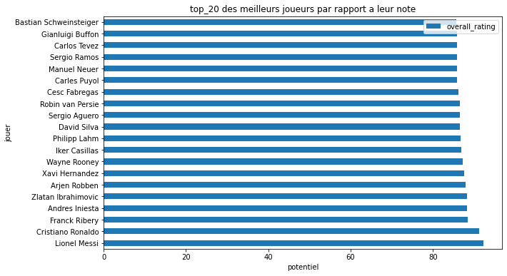

```python
Barplot(top_20_best_players,'top_20 des meilleurs joueurs par rapport a leur note','potentiel','jouer')
```

### Question de recherche 6(quel est le top 10 des joueurs ayant du haut potentiels ?)

```python
#grouper la table joueur par nom et pieds de  preferance pour caluler par par la suite le mean de toutes les valeurs et
#extraire la valeur moyenne du potential de chaque joueur
best_players=players2.groupby(['player_api_id','player_name','preferred_foot']).mean().sort_values(by=["potential"],ascending=False)
```

```python
top_10_best_players=best_players.head(10)
top_10_best_players.reset_index(inplace=True)
```

#### Liste des 10 joueurs ayant un haut potential

```python
top_10_best_players
```

|  | player_api_id | player_name | preferred_foot | overall_rating | potential | penalties | marking | height | weight | age | year |
| --- | --- | --- | --- | --- | --- | --- | --- | --- | --- | --- | --- |
| 0 | 30981 | Lionel Messi | left | 92.192308 | 95.230769 | 80.153846 | 18.769231 | 170.18 | 159.0 | 35.0 | 2012.230769 |
| 1 | 30893 | Cristiano Ronaldo | right | 91.280000 | 93.480000 | 83.600000 | 22.120000 | 185.42 | 176.0 | 37.0 | 2012.080000 |
| 2 | 31013 | Theo Walcott | left | 76.000000 | 93.000000 | 64.000000 | 23.000000 | 175.26 | 150.0 | 33.0 | 2007.000000 |
| 3 | 37412 | Sergio Aguero | left | 80.000000 | 91.000000 | 72.000000 | 19.000000 | 172.72 | 163.0 | 34.0 | 2007.000000 |
| 4 | 34520 | Fabio Cannavaro | right | 85.166667 | 90.833333 | 84.833333 | 90.666667 | 175.26 | 165.0 | 48.0 | 2008.333333 |
| 5 | 19533 | Neymar | right | 83.800000 | 90.760000 | 79.760000 | 21.000000 | 175.26 | 150.0 | 30.0 | 2012.840000 |
| 6 | 30955 | Andres Iniesta | right | 88.320000 | 90.560000 | 71.120000 | 58.240000 | 170.18 | 150.0 | 38.0 | 2011.840000 |
| 7 | 177714 | Mario Goetze | right | 83.176471 | 90.147059 | 66.705882 | 20.617647 | 175.26 | 159.0 | 30.0 | 2013.294118 |
| 8 | 35724 | Zlatan Ibrahimovic | right | 88.285714 | 90.047619 | 88.000000 | 20.904762 | 195.58 | 209.0 | 40.0 | 2011.380952 |
| 9 | 108568 | Ever Banega | left | 71.000000 | 90.000000 | 52.000000 | 74.000000 | 175.26 | 157.0 | 34.0 | 2007.333333 |

```python
top_10_best_players=top_10_best_players[["player_name","potential"]].set_index("player_name").sort_values("potential",ascending=True)
```

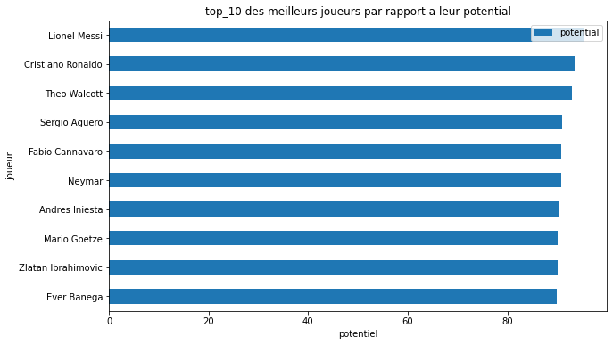

```python
Barplot(top_10_best_players,'top_10 des meilleurs joueurs par rapport a leur potential','potentiel','joueur')
```

```python
detailed_matches
```

|  | id | country_name | league_name | season | stage | date | home_team | away_team | home_team_goal | away_team_goal |
| --- | --- | --- | --- | --- | --- | --- | --- | --- | --- | --- |
| 0 | 24559 | Switzerland | Switzerland Super League | 2008/2009 | 1 | 2008-07-18 00:00:00 | BSC Young Boys | FC Basel | 1 | 2 |
| 1 | 24560 | Switzerland | Switzerland Super League | 2008/2009 | 1 | 2008-07-19 00:00:00 | FC Aarau | FC Sion | 3 | 1 |
| 2 | 24561 | Switzerland | Switzerland Super League | 2008/2009 | 1 | 2008-07-20 00:00:00 | FC Luzern | FC Vaduz | 1 | 2 |
| 3 | 24562 | Switzerland | Switzerland Super League | 2008/2009 | 1 | 2008-07-20 00:00:00 | Neuchâtel Xamax | FC Zürich | 1 | 2 |
| 4 | 24613 | Switzerland | Switzerland Super League | 2008/2009 | 2 | 2008-07-23 00:00:00 | FC Basel | Grasshopper Club Zürich | 1 | 0 |
| ... | ... | ... | ... | ... | ... | ... | ... | ... | ... | ... |
| 25974 | 25945 | Switzerland | Switzerland Super League | 2015/2016 | 36 | 2016-05-25 00:00:00 | FC Basel | Grasshopper Club Zürich | 0 | 1 |
| 25975 | 25946 | Switzerland | Switzerland Super League | 2015/2016 | 36 | 2016-05-25 00:00:00 | Lugano | FC St. Gallen | 3 | 0 |
| 25976 | 25947 | Switzerland | Switzerland Super League | 2015/2016 | 36 | 2016-05-25 00:00:00 | FC Luzern | FC Sion | 2 | 2 |
| 25977 | 25948 | Switzerland | Switzerland Super League | 2015/2016 | 36 | 2016-05-25 00:00:00 | FC Thun | BSC Young Boys | 0 | 3 |
| 25978 | 25949 | Switzerland | Switzerland Super League | 2015/2016 | 36 | 2016-05-25 00:00:00 | FC Zürich | FC Vaduz | 3 | 1 |

25979 rows × 10 columns

```python
#Code
#recuperer les information de la ligue de France
detail_matche_fr=detailed_matches.query("country_name=='France'")
#grouper les elements par saison et faire la somme des buts marqués
but_par_saison=detail_matche_fr.groupby('season').sum()
#etant donné qu'il ya deux colonnes goal les additionner pour avoir le total de but
but_par_saison['total']=but_par_saison['home_team_goal']+but_par_saison['away_team_goal']
#but_par_saison.reset_index(inplace=True)
but_par_saison.reset_index(inplace=True)
#trier mes données par au but par ordre croissant
but_par_saison.sort_values(by='total',inplace=True)
```

```python
#Plot
total_but=but_par_saison["total"].sort_values(ascending=True)
total_but
```

```
0    858
2    890
1    916
5    933
6    947
3    956
7    960
4    967
Name: total, dtype: int64
```

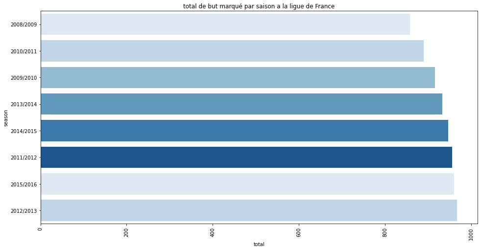

```python
plt.figure(figsize = (16,8))
ax=sns.barplot(data=but_par_saison,x="total",y="season",palette= sns.color_palette("Blues"));
ax.set(title="total de but marqué par saison a la ligue de France")
for item in ax.get_xticklabels():
    item.set_rotation(90)
plt.show()
```

**Conclusion**

A LA Ligue 1 de france la saison a laquelle on a comptabilisé le plus de but est la saison 2012/2013

### Question de recherche 8 (combien de match ont été joués / chaque league?)

```python
detailed_matches
```

|  | id | country_name | league_name | season | stage | date | home_team | away_team | home_team_goal | away_team_goal |
| --- | --- | --- | --- | --- | --- | --- | --- | --- | --- | --- |
| 0 | 24559 | Switzerland | Switzerland Super League | 2008/2009 | 1 | 2008-07-18 00:00:00 | BSC Young Boys | FC Basel | 1 | 2 |
| 1 | 24560 | Switzerland | Switzerland Super League | 2008/2009 | 1 | 2008-07-19 00:00:00 | FC Aarau | FC Sion | 3 | 1 |
| 2 | 24561 | Switzerland | Switzerland Super League | 2008/2009 | 1 | 2008-07-20 00:00:00 | FC Luzern | FC Vaduz | 1 | 2 |
| 3 | 24562 | Switzerland | Switzerland Super League | 2008/2009 | 1 | 2008-07-20 00:00:00 | Neuchâtel Xamax | FC Zürich | 1 | 2 |
| 4 | 24613 | Switzerland | Switzerland Super League | 2008/2009 | 2 | 2008-07-23 00:00:00 | FC Basel | Grasshopper Club Zürich | 1 | 0 |
| ... | ... | ... | ... | ... | ... | ... | ... | ... | ... | ... |
| 25974 | 25945 | Switzerland | Switzerland Super League | 2015/2016 | 36 | 2016-05-25 00:00:00 | FC Basel | Grasshopper Club Zürich | 0 | 1 |
| 25975 | 25946 | Switzerland | Switzerland Super League | 2015/2016 | 36 | 2016-05-25 00:00:00 | Lugano | FC St. Gallen | 3 | 0 |
| 25976 | 25947 | Switzerland | Switzerland Super League | 2015/2016 | 36 | 2016-05-25 00:00:00 | FC Luzern | FC Sion | 2 | 2 |
| 25977 | 25948 | Switzerland | Switzerland Super League | 2015/2016 | 36 | 2016-05-25 00:00:00 | FC Thun | BSC Young Boys | 0 | 3 |
| 25978 | 25949 | Switzerland | Switzerland Super League | 2015/2016 | 36 | 2016-05-25 00:00:00 | FC Zürich | FC Vaduz | 3 | 1 |

25979 rows × 10 columns

```python
detailed_matches
```

|  | id | country_name | league_name | season | stage | date | home_team | away_team | home_team_goal | away_team_goal |
| --- | --- | --- | --- | --- | --- | --- | --- | --- | --- | --- |
| 0 | 24559 | Switzerland | Switzerland Super League | 2008/2009 | 1 | 2008-07-18 00:00:00 | BSC Young Boys | FC Basel | 1 | 2 |
| 1 | 24560 | Switzerland | Switzerland Super League | 2008/2009 | 1 | 2008-07-19 00:00:00 | FC Aarau | FC Sion | 3 | 1 |
| 2 | 24561 | Switzerland | Switzerland Super League | 2008/2009 | 1 | 2008-07-20 00:00:00 | FC Luzern | FC Vaduz | 1 | 2 |
| 3 | 24562 | Switzerland | Switzerland Super League | 2008/2009 | 1 | 2008-07-20 00:00:00 | Neuchâtel Xamax | FC Zürich | 1 | 2 |
| 4 | 24613 | Switzerland | Switzerland Super League | 2008/2009 | 2 | 2008-07-23 00:00:00 | FC Basel | Grasshopper Club Zürich | 1 | 0 |
| ... | ... | ... | ... | ... | ... | ... | ... | ... | ... | ... |
| 25974 | 25945 | Switzerland | Switzerland Super League | 2015/2016 | 36 | 2016-05-25 00:00:00 | FC Basel | Grasshopper Club Zürich | 0 | 1 |
| 25975 | 25946 | Switzerland | Switzerland Super League | 2015/2016 | 36 | 2016-05-25 00:00:00 | Lugano | FC St. Gallen | 3 | 0 |
| 25976 | 25947 | Switzerland | Switzerland Super League | 2015/2016 | 36 | 2016-05-25 00:00:00 | FC Luzern | FC Sion | 2 | 2 |
| 25977 | 25948 | Switzerland | Switzerland Super League | 2015/2016 | 36 | 2016-05-25 00:00:00 | FC Thun | BSC Young Boys | 0 | 3 |
| 25978 | 25949 | Switzerland | Switzerland Super League | 2015/2016 | 36 | 2016-05-25 00:00:00 | FC Zürich | FC Vaduz | 3 | 1 |

25979 rows × 10 columns

```python
#Code
#grouper les latch par league et compter le nombre de match total par league
t2=detailed_matches.groupby(['league_name']).league_name.count()
```

```python
t2.sort_values(inplace=True)
t2
```

```
league_name
Switzerland Super League    1422
Belgium Jupiler League      1728
Scotland Premier League     1824
Poland Ekstraklasa          1920
Portugal Liga ZON Sagres    2052
Germany 1. Bundesliga       2448
Netherlands Eredivisie      2448
Italy Serie A               3017
England Premier League      3040
France Ligue 1              3040
Spain LIGA BBVA             3040
Name: league_name, dtype: int64
```

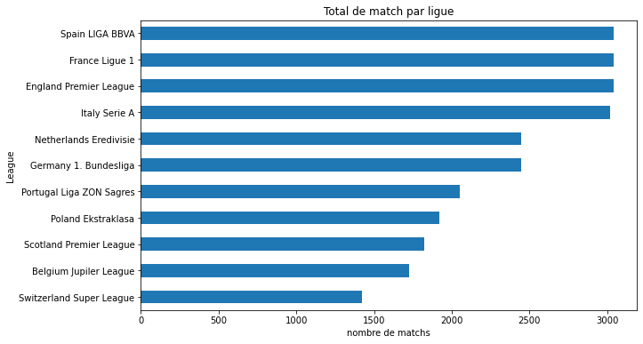

```python
#Plot
Barplot(t2,'Total de match par ligue','nombre de matchs','League')
```

**Conclusion**

### Question de recherche 9 (-quelles sont les meilleurs equipes des derniere season la derniere année pour chaque league en terme de nombre de but?)

#### on recupère les matchs de la derniere saison

```python
saison1516_matches=detailed_matches[detailed_matches["season"]=="2015/2016"]
#saison1516_matches[saison1516_matches["Home_team_name"]==saison1516_matches["Away_team_name"]]
saison1516_matches.set_index(["country_name","league_name"])
l1=saison1516_matches[["league_name","home_team","away_team","home_team_goal","away_team_goal"]].sort_values(by=['away_team_goal'],ascending=False).head(10)
```

```python
#### la on recuperer les equipes qui jouent en terre etrangères et qui ont marqués
```

```python
#un nombre important de but a un match
l1=l1[["away_team","away_team_goal"]]
l1=l1.rename(columns={"away_team":"team","away_team_goal":"goal"})
l1
```

|  | team | goal |
| --- | --- | --- |
| 25253 | Paris Saint-Germain | 9 |
| 25649 | FC Barcelona | 8 |
| 25619 | FC Basel | 7 |
| 23074 | PSV | 6 |
| 25453 | FC Sion | 6 |
| 24833 | AZ | 6 |
| 23167 | Wisła Kraków | 6 |
| 23685 | PSV | 6 |
| 24397 | Sporting CP | 6 |
| 23087 | Real Madrid CF | 6 |

```python
#filtre par ordre decroissant
l2=saison1516_matches[["league_name","home_team","away_team","home_team_goal","away_team_goal"]].sort_values(by=['home_team_goal'],ascending=False).head(10)
```

```python
#la on recuperer les equipes qui jouent a domicile et qui ont marqués
#un nombre important de but a un match
l2=l2[["home_team","home_team_goal"]]
l2=l2.rename(columns={"home_team":"team","home_team_goal":"goal"})
l2
```

|  | team | goal |
| --- | --- | --- |
| 24291 | Real Madrid CF | 10 |
| 24523 | Celtic | 8 |
| 22998 | Club Brugge KV | 7 |
| 25956 | Celtic | 7 |
| 25515 | BSC Young Boys | 7 |
| 25152 | Real Madrid CF | 7 |
| 22909 | Olympique de Marseille | 6 |
| 25822 | Olympique Lyonnais | 6 |
| 24879 | FC Barcelona | 6 |
| 24808 | KRC Genk | 6 |

```python
top_5_best_team_goal=l1.append(l2)
top_5_best_team_goal=top_5_best_team_goal.sort_values("goal",ascending=False)
top_5_best_team_goal.drop_duplicates(subset="team",inplace=True,keep='first')
```

```python
#top_5_best_team_goal.drop_duplicates(subset="goal",inplace=True,keep='first')
```

```python
top_5_best_team_goal.set_index("team",inplace=True)
```

```python
top_5_best_team_goal=top_5_best_team_goal.head(5)
```

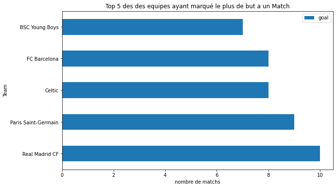

```python
#Plot
Barplot(top_5_best_team_goal,'Top 5 des des equipes ayant marqué le plus de but a un Match','nombre de matchs','Team')
```

```python
#desactiver ma connexion au fichier sqlite
con.close()
```

## Conclusions

> 1-la proportion des joueurs préferant jouer avec le pieds droit répresente la majorité soit 3/4 tandis que les 1/4 répresentent les joueurs préferant jouer avec le pieds gauche ,cette characteristique n'a aucune relation avec le potentiel du joueur ou la note octroyé au joueur .

> 2-la majeur parti des joueurs ont un age compris entre 30 et 40. l'age moyen se trouvant etre 35 ans toutes les ligues confondus.il faudrait pas oublier que cette base de donnée concerne les ligues des saison allant de 2007 a 2016 .

> 3-la characteristique potentiel du joueur est celle qui influence le plus le rating(la note du joueur).

> 4-La relation entre le poids et la taille des joueurs est justifié car scientifiquement prouver, plus le joueur est grand plus son poids serait elevé.Cependant ces deux characteristiques n'influence en aucun cas la note des joueurs qui ,elle pour l'instant est beaucoup plus influencé par le potentiel du joueur.

> 5-top 20 des joueurs le mieux notés.  
> 'Lionel Messi'  
> 'Cristiano Ronaldo',  
> 'Franck Ribery',  
> 'Andres Iniesta',  
> 'Zlatan Ibrahimovic',  
> 'Arjen Robben',  
> 'Xavi Hernandez',  
> 'Wayne Rooney',  
> 'Iker Casillas',  
> 'Philipp Lahm',  
> 'David Silva',  
> 'Sergio Aguero',  
> 'Robin van Persie',  
> 'Cesc Fabregas',  
> 'Carles Puyol',  
> 'Manuel Neuer',  
> 'Sergio Ramos',  
> 'Carlos Tevez',  
> 'Gianluigi Buffon',  
> 'Bastian Schweinsteiger

> 6-top 10 joueur a fort potentiel  
> Ever Banega  
> Zlatan Ibrahimovic  
> Mario Goetze  
> Andres Iniesta  
> Neymar  
> Fabio Cannavaro  
> Sergio Aguero  
> Theo Walcott  
> Cristiano Ronaldo  
> Lionel Messi

> 7-La saison 2012-2013 de la ligue Francaise compte 967 buts marqués par rapport au autres saisons ,c'est la saison ou le plus de but a ete marqué a ligue 1 francaise.

> 8- la ligue d'espagne de France et Angleterre comptabilise le meme nombre de match et le plus grand nombre de match par rapport au autre League Switzerland Super League 1422 Belgium Jupiler League 1728 Scotland Premier League 1824 Poland Ekstraklasa 1920 Portugal Liga ZON Sagres 2052 Germany 1. Bundesliga 2448 Netherlands Eredivisie 2448 Italy Serie A 3017 England Premier League 3040 France Ligue 1 3040 Spain LIGA BBVA 3040.

> 9 - les equipes ayant marqué le plus de but a un match lors de la dernière saison toute ligue confondu sont en premier le Real Madrid avec 10 buts ensuite suit le PSG,Celtic et Fc Barcelona et bsc young boys

## Limitations:

les tables de Player_attributes et Players qui contiennent les informations des joueurs ne precisent pas les clubs des joueurs ce qui rend difficiles l'analyse complète d'une ligue et des joueurs associés . on ne peut donc pas designer les meilleurs buteurs de ligues ou meilleur attaquant d'equipe et autres.

En outre on ne retrouve pas aussi les postes des joueurs ,car il est bien normal qu'un gardien ne soit pas meilleurs butteurs donc en se focalisant sur le nombre de but marquer on ne pas classer les gardiens de match.

> SOURCE  
> https://stackoverflow.com/questions/49739123/importing-sql-query-into-pandas-results-in-only-1-column  
> https://Kaggle.com  
> https://askcodez.com/